# Navegabilidad Rio Magdalena

1Michael Steven Bonilla, 2[Juan C. Correa](https://scholar.google.com/citations?user=fb0nE80AAAAJ&hl=en)

1[Universidad del Rosario, Bogotá, Colombia](https://urosario.edu.co/), 2[Critical Centrality Institute, Monterrey, México](https://www.criticalcentrality.com/inicio)

## Situación Problema

El río Magdalena es una de las más importantes arterias fluviales de Colombia. Si Colombia desarrolla la infraestructura necesaria para el transporte fluvial del Magdalena, el país podría con el transporte nacional más seguro, barato y funcional, que reemplazaría con eficacia las rutas de tráfico terrestre llena de transporte de carga que resultan difíciles de mantener.

[video not shown]

Según el gobernador del departamento del Atlántico, [Eduardo Verano de la Rosa](https://www.larepublica.co/analisis/eduardo-verano-de-la-rosa-500119/retos-del-rio-magdalena-3509151#:~:text=La%20navegabilidad%20del%20Rio%20Magdalena,vez%20m%C3%A1s%20dif%C3%ADciles%20de%20mantener.) (2022), para lograr la navegabilidad del río magdalena se necesitan ejecutar los siguientes cinco proyectos:

1. **Proyecto del Puerto de Aguas profundas** en la punta del tajamar occidental con un canal de acceso de 20mts de profundidad qué permitirá el acceso de barcos de 200.000 toneladas.
2. **Proyecto de acceso al río Magdalena** desde Bocas de Cenizas hasta el Puente Pumarejo con 20 puertos que existen a lo largo de sus 30kms. Se requiere una serie de obras rígidas y dragados qué mantendrán la navegabilidad con 10 diez metros de profundidad para barcos de 35.000 toneladas. Estas obras rígidas con diques y enrocados son más costosas en un principio, pero más funcionales y rentables en largo plazo.
3. **Proyecto de Navegabilidad Barranquilla-Barrancabermeja** del río desde el puente en Barranquilla hasta Barrancabermeja, con una distancia de 631 km que requiere un mantenimiento a través de dragados y obras de ingeniería que garanticen su navegabilidad permanente. Este proyecto se denomina APP del Río Magdalena y requiere una inversión de casi $2 billones y se financiará a través de peajes impulsado por el sector privado con el apoyo y dirección del Gobierno Nacional.
4. **Proyecto de Navegabilidad Barrancabermeja-Puerto Salgar** Puerto Salgar es un punto geográfico estratégico porque puede recibir la producción industrial desde Bogotá y luego hacerla llegar vía fluvial hasta Barranquilla que está a 886 Km de distancia de Puerto Salgar.
5. **Proyecto Canal del Dique** que implica el aprovechamiento de 130 km que requieren dos esclusas y otros componentes por valor total de $ 3 Billones que regulan el volumen de aguas y facilitan su navegabilidad, también controlará las inundaciones en el norte de Bolívar y sur del Atlántico, y lo más importante garantizará el suministro de agua potable para Cartagena.

Estos cinco proyectos interrelacionados son indispensables para el desarrollo estratégico de Colombia. Cada proyecto es complementario a los demás y aunque tienen objetivos diferentes, todos pertenecen a una visión unificada e integral.

## Agencias Financiadoras

Dada la magnitud de este proyecto complejo, resulta obvio encontrar que la primera agencia financiadora de su desarrollo sea el gobierno nacional de Colombia. Según reportes de la Radio Nacional de Colombia, el 30 de Noviembre de 2022 se confirmó que el Gobierno Nacional confirmó 2.2 billones de pesos colombianos para realizar obras que mejoren la navegabilidad del río Magdalena.

Con el propósito de aprender cómo implementar la evaluación financiera de proyectos de desarrollo de alta complejidad, acá vamos a usar los datos públicos del plan de adquisiciones de [Cormagdalena](https://cormagdalena.gov.co/contratacion/#plan-adquisiciones).

Cormagdalena es una corporación de carácter público con participación de entidades privadas que está orientada a garantizar “la protección y gestión integral del río Magdalena como un bien público a su cargo, que en su conjunto constituye un sistema multidimensional, con el fin de contribuir al aumento del desarrollo competitivo del país, al mejoramiento de la calidad de vida de las comunidades ribereñas y a la protección del derecho de todos los colombianos a gozar de un ambiente sano”.

## Datos de Cormagdalena

Al explorar los datos relacionados con el plan de Adquisiciones de Cormagdalena para el año 2024, nos encontramos una serie de 219 licitaciones públicas orientadas a contratar los servicios o productos de proveedores locales. Estas licitaciones van dirigidas de manera específica a cada una de las ciudades involucradas en el mega-proyecto de navegabilidad del rio magdalena. Por ello, para saber cuáles licitaciones se necesitan en cada ciudad, vale la pena construir una tabla donde veamos las relaciones entre las licitaciones y los departamentos.

```r
library(readxl)
PAA_2024 <- read_excel("Data/PAA-2024.xlsx")
library(dplyr)
correosBogota <- filter(PAA_2024, grepl('Bogotá', Ubicación))
correosBarrancabermeja <- filter(PAA_2024, grepl('Barrancabermeja', Ubicación))
unique(correosBogota$`Correo electrónico del responsable`)
```

```
## [1] "maria.guerrero@cormagdalena.gov.co" "oriana.carbono@cormagdalena.gov.co"
## [3] "diana.delgado@cormagdalena.gov.co"  "maria.paez@cormagdalena.gov.co"
## [5] "nubia.quevedo@cormagdalena.gov.co"  "alvaro.redondo@cormagdalena.gov.co"
## [7] "maria.suarez@cormagdalena.gov.co"
```

```r
unique(correosBarrancabermeja$`Correo electrónico del responsable`)
```

```
## [1] "maria.paez@cormagdalena.gov.co"     "nubia.quevedo@cormagdalena.gov.co"
## [3] "maria.suarez@cormagdalena.gov.co"   "alvaro.redondo@cormagdalena.gov.co"
```

```r
table(correosBogota$`Modalidad de selección`)
```

```
##
##         Concurso de méritos abierto               Contratación directa.
##                                   1                                  19
##       Contratación régimen especial                      Mínima cuantía
##                                   1                                   2
## Seléccion abreviada - acuerdo marco   Selección abreviada menor cuantía
##                                   1                                   3
```

Esta tabla de datos cuenta con un total de 19 columnas (variables) resumidas así:

```r
variable.names(PAA_2024)
```

```
##  [1] "Código UNSPSC (cada código separado por ;)"
##  [2] "Descripción"
##  [3] "Fecha estimada de inicio de proceso de selección (mes)"
##  [4] "Fecha estimada de presentación de ofertas (mes)"
##  [5] "Duración del contrato (número)"
##  [6] "Duración del contrato (intervalo: días, meses, años)"
##  [7] "Modalidad de selección"
##  [8] "Fuente de los recursos"
##  [9] "Valor total estimado"
## [10] "Valor estimado en la vigencia actual"
## [11] "¿Se requieren vigencias futuras?"
## [12] "Estado de solicitud de vigencias futuras"
## [13] "Unidad de contratación (referencia)"
## [14] "Ubicación"
## [15] "Nombre del responsable"
## [16] "Teléfono del responsable"
## [17] "Correo electrónico del responsable"
## [18] "¿Debe cumplir con invertir mínimo el 30% de los recursos del presupuesto destinados a comprar alimentos, cumpliendo con lo establecido en la Ley 2046 de 2020, reglamentada por el Decreto 248 de 2021?"
## [19] "¿El contrato incluye el suministro de bienes y servicios distintos a alimentos?"
```

Para observar con detalle cuánto dinero está presupuestado para las 219 licitaciones públicas, solo falta concentrarse en las columna 2 (“Descripción”) y la columna 10 (“Valor estimado en la vigencia actual”). Las cifras están en pesos colombianos.

```r
library(knitr)
library(broom)
library(kableExtra)
data <- readxl::read_excel("Data/PAA-2024.xlsx")
data <- data[c(2,10)]
html_table <- kable(data, format = "html")%>%
  kable_styling()

# Print the HTML table
html_table
```

| Descripción | Valor estimado en la vigencia actual |
| --- | --- |
| 3-CONTRATAR EL SERVICIO INTEGRAL DE ASEO Y CAFETERIA PARA LA CORPORACIÓN AUTONOMA REGIONAL DEL RIO GRANDE DE LA MAGDALENA - CORMAGDALENA | 81000000 |
| 4-CONTRATAR EL SERVICIO INTEGRAL DE ASEO Y CAFETERIA PARA LA CORPORACIÓN AUTONOMA REGIONAL DEL RIO GRANDE DE LA MAGDALENA - CORMAGDALENA | 9000000 |
| 5-CONTRATAR EL SERVICIO DE MANTENIMIENTO PREVENTIVO Y CORRECTIVO, INCLUIDOS REPUESTOS, PARA LOS AUTOMOVILES DE LA CORPORACIÓN AUTÓNOMA REGIONAL DEL RIO GRANDE DE LA MAGDALENA - CORMAGDALENA EN LA CIUD… | 85000000 |
| 6-ADQUISICIÓN E IMPLEMENTACIÓN SOLUCIÓN TECNOLOGICA MODELO INTEGRADO DE PLANEACIÓN Y GESTIÓN - MIPG, PARA LA CORPORACIÓN AUTÓNOMA REGIONAL DEL RÍO GRANDE DE LA MAGDALENA - CORMAGDALENA | 300000000 |
| 7-RENOVACIÓN LICENCIA SUITE VISION | 25000000 |
| 8-REALIZAR LA INTERVENTORÍA ADMINISTRATIVA, TÉCNICA, FINANCIERA, CONTABLE Y JURÍDICA PARA LOS SIGUIENTES CONTRATOS DE CONCESIÓN PORTUARIA - GRUPO 1 | 1123140500 |
| 9-REALIZAR LA INTERVENTORÍA ADMINISTRATIVA, TÉCNICA, FINANCIERA, CONTABLE Y JURÍDICA PARA LOS SIGUIENTES CONTRATOS DE CONCESIÓN PORTUARIA - GRUPO 2 | 1123140500 |
| 10-REALIZAR EL AVALUO DEL BIEN CONCESIONADO PARA EL PROCESO DE TERMINACION Y REVERSION DE LA CONCESION PORTUARIA | 30000000 |
| 11-ADQUISICIÓN DE SOFTWARE PARA LA ORGANIZACIÓN, INTEGRACIÓN, PLANIFICACIÓN, ANÁLISIS Y SEGUIMIENTO DE LA ACTIVIDAD PORTUARIA Y/O NO PORTUARIA DE CORMAGDALENA | 700000000 |
| 12-PRESTAR EL SERVICIO DE DIFUSIÓN DE CONTENIDOS VISUALES, AUDITIVOS Y AUDIOVISUALES DE CORMAGDALENA, EN FORMATOS DE ALTA CALIDAD, PARA SU EMISIÓN EN DIFERENTES PLATAFORMAS Y TECNOLOGÍAS A TRAVÉS DEL … | 500000000 |
| 13-CONTRATAR LOS SERVICIOS DE OPERACIÓN LOGÍSTICA PARA LA ORGANIZACIÓN Y EJECUCIÓN DE EVENTOS QUE REQUIERA LA ENTIDAD CONTRIBUYENDO A LA CONSOLIDACIÓN Y FORTALECIMIENTO DE LA IMAGEN INSTITUCIONAL DE L… | 660000000 |
| 14-SERVICIO DE DESCONTAMINACIÓN DE LAS ORILLAS DE LA RIBERA DEL RIO MAGDALENA | 250000000 |
| 15-ARRENDAMIENTO INCLUIDA LA ADMINISTRACIÓN DE INMUEBLE DESTINADO AL FUNCIONAMIENTO DE LA OFICINA DE GESTIÓN Y ENLACE DE LA CORPORACIÓN AUTONOMA REGIONAL DEL RIO GRANDE DE LA MAGDALENA CORMAGDALENA EN… | 44351980 |
| 16-CONSULTORIA DEL ESTADO ACTUAL DEL AREA DE SISTEMAS Y TECNOLOGIAS PARA LA CORPORACIÓN AUTONMA REGIONAL DEL RIO GRANDE DE LA MAGDALENA (CORMAGDALENA) | 550000000 |
| 17-CONTRATAR LA SUSCRIPCIÓN DE LICENCIAS DEL SOFTWARE ADOBE CREATIVE CLOUD (TODAS LAS APLICACIONES) PARA CORMAGDALENA | 8576000 |
| 18-CONTRATAR LA SUSCRIPCIÓN DE LICENCIAS DE MICROSOFT OFFICE 365 E3 OPEN, LICENCIA DE MICROSOFT PROJECT ONLINE PROFESSIONAL, POWER BI Y LICENCIAS DE WINDOWS SERVER 2022 ESTÁNDAR | 428107202 |
| 19-ADQUISICION DE LICENCIAS ANTIVIRUS KASPERSKY ENDPOINT SECURITY CLOUD PRO, CON SOPORTE Y ACTUALIZACIÓN PARA LA CORPORACIÓN AUTÓNOMA REGIONAL DEL RÍO GRANDE DE LA MAGDALENA – CORMAGDALENA | 109938960 |
| 20-ADQUISICION DE UN FIREWALL (CORTAFUEGOS) Y RENOVACIÓN DE LICENCIAS DEL SOFTWARE DE SEGURIDAD PERIMETRAL PARA LA RED, SERVIDORES Y EQUIPOS DE COMPUTO DE LA CORPORACION – CORMAGDALENA | 55744000 |
| 21-CONTRATAR EL SERVICIO DE CERTIFICADOS DE FIRMAS DIGITALES Y CERTIFICADO DE SEGURIDAD SSL PARA CORMAGDALENA | 30016000 |
| 22-CONTRATAR BAJO LA MODALIDAD DE SERVICIO (SaaS - SOFTWARE AS A SERVICE), EL SISTEMA INTEGRAL QUE CONTEMPLA EL SISTEMA ADMINISTRATIVO Y FINANCIERO, EL SISTEMA DE GESTION DOCUMENTAL Y EL SISTEMA DE RE… | 1405165964 |
| 23-MIGRACIÓN Y RENOVACIÓN DEL HOSTING DEL SITIO WEB DE LA ENTIDAD Y ACTUALIZACIÓN DEL GESTOR DE CONTENIDOS INCLUYE MEJORAS Y AFINAMIENTOS DEL PORTAL WEB DE ACUERDO A LOS LINEAMIENTOS DE GOBIERNO EN LI… | 53600000 |
| 24-MANTENIMIENTO PREVENTIVO Y CORRECTIVO DEL SISTEMA DE SEGURIDAD CCTV EN LA SEDE PRINCIPAL DE BARRANCABERMEJA DE LA CORPORACIÓN CORMAGDALENA | 21440000 |
| 25-ADQUISICIÓN, INSTALACIÓN, CONFIGURACIÓN Y PUESTA EN FUNCIONAMIENTO DE EQUIPOS SWITCHES CORE ADMINISTRABLES PARA LAS SEDES DE BARRANCABERMEJA, BOGOTA, BARRANQUILLA | 45024000 |
| 26-CONTRATAR LA PRESTACIÓN DE SERVICIOS DE INTERNET Y ENLACES WAN PARA LA RED CORPORATIVA VOZ Y DATOS PARA LAS SEDES DE LA CORPORACION CORMAGDALENA | 541000000 |
| 27-PRESTACIÓN DE SERVICIOS DE MANTENIMIENTO PREVENTIVO Y CORRECTIVO DE EQUIPOS DE POTENCIA UBICADOS EN LAS SEDES DE LA CORPORACIÓN AUTÓNOMA REGIONAL DEL RIO GRANDE DE LA MAGDALENA - CORMAGDALENA | 42880000 |
| 28-ACTUALIZACIÓN, ADECUACIÓN Y MANTENIMIENTO DE LA INFRAESTRUCTURA TECNOLÓGICA DE LAS SEDES BARRANCABERMEJA | 482400000 |
| 29-CONTRATAR LA ADQUISICIÓN DE EQUIPOS TECNOLÓGICOS, PORTÁTILES, EQUIPOS DE CÓMPUTO, ESTACIONES DE TRABAJO, PERIFÉRICOS DE TECNOLOGÍA, CÁMARA WEB, DISCOS DUROS DE ESTADO SÓLIDO, PARA EL FORTALECIMIENT… | 1070000000 |
| 30-RENOVACION DEL BLOQUE DEL POOL DE DIRECCIONAMIENTO IPV-6 Y MEMBRESIA ASN ANTE LA LACNIC CON SOPORTE ESPECIALIZADO PARA LA VINCULACION DE EQUIPAMIENTO NUEVO PARA LA INFRAESTRUCTURA DE RED DE DATOS D… | 22560000 |
| 31-RENOVACION DEL LICENCIAMIENTO DE LA INFRAESTRUCTURA DE COMUNICACIONES UNIFICADAS DE VOZ Y DATOS 3CX PROFESIONAL Y AFINAMIENTO DE LA ESTRUCTURA ACTUAL PARA LAS SEDES DE BARRANCABERMEJA, BARRANQUILLA… | 38750000 |
| 32-ADQUISICIÓN DE COMPONENTES TECNOLOGICOS DE VIDEOCONFERENCIA PARA LA ADECUACION DE LA SALA DE JUNTAS BARRANCABERMEJA | 92370000 |

[output cut: 189 more lines]

Una breve visualización de datos nos ayuda a entender cómo es la distribución estadística de esos presupuestos por mes (columna 4).

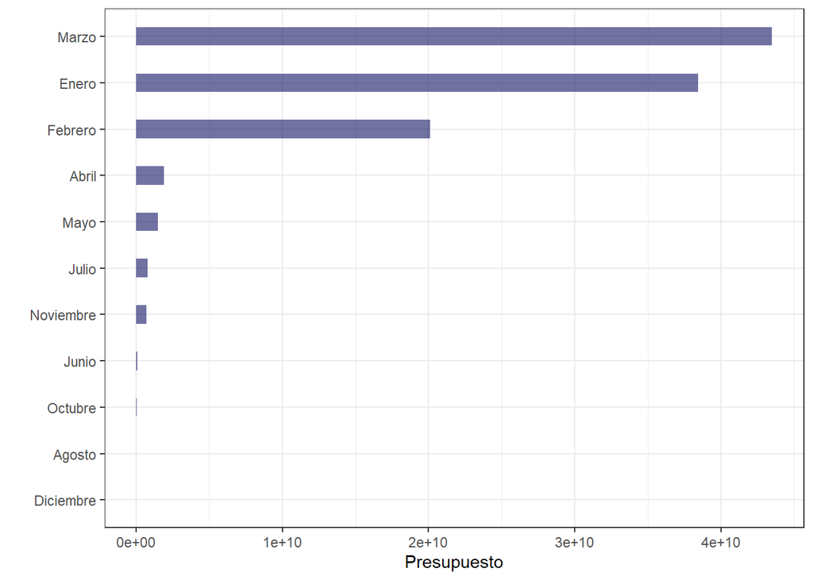

```r
data <- readxl::read_excel("Data/PAA-2024.xlsx")
data <- na.omit(data[c(4,10)])
colnames(data)[1] <- "Mes"
colnames(data)[2] <- "Valor"
library(dplyr)
resumen <- data %>%
 group_by(Mes) %>%
 summarize(Presupuesto = sum(Valor, na.rm = TRUE))



library(ggplot2)

ggplot(resumen, aes(x=reorder(Mes, Presupuesto), y=Presupuesto)) +
    geom_bar(stat="identity", fill="#131364", alpha=.6, width=.4) +
    coord_flip() +
    xlab("") +
    theme_bw()
```

Para determinar a cuanto asciende el valor de inversión de todas las licitaciones, basta con traer el “valor” y sumar los valores de esa columna

```r
data <- readxl::read_excel("Data/PAA-2024.xlsx")
data <- na.omit(data[c(9)])
valor_total_inversion <- sum(data$`Valor total estimado`, na.rm = TRUE)
print(valor_total_inversion)
```

```
## [1] 109255896208
```

[video not shown]

Para observar los correos de los responsables de las licitaciones, se debe concentrar en traer las columnas 2 (“descripción”) la columna 7 (“modalidad de selección”) la columna 14 (“ubicación”) la columna 15(“Nombre del responsable”) y la columna 17(correo electrónico del responsable”)

```r
library(knitr)
library(broom)
library(kableExtra)
data <- readxl::read_excel("Data/PAA-2024.xlsx")
data <- data[c(2,7,14,15,17)]
html_table <- kable(data, format = "html")%>%
  kable_styling()

# Print the HTML table
html_table
```

| Descripción | Modalidad de selección | Ubicación | Nombre del responsable | Correo electrónico del responsable |
| --- | --- | --- | --- | --- |
| 3-CONTRATAR EL SERVICIO INTEGRAL DE ASEO Y CAFETERIA PARA LA CORPORACIÓN AUTONOMA REGIONAL DEL RIO GRANDE DE LA MAGDALENA - CORMAGDALENA | Seléccion abreviada - acuerdo marco | Atlántico - Barranquilla | María Patria Suárez Leiva | maria.suarez@cormagdalena.gov.co |
| 4-CONTRATAR EL SERVICIO INTEGRAL DE ASEO Y CAFETERIA PARA LA CORPORACIÓN AUTONOMA REGIONAL DEL RIO GRANDE DE LA MAGDALENA - CORMAGDALENA | Seléccion abreviada - acuerdo marco | Atlántico - Barranquilla | María Patria Suárez Leiva | maria.suarez@cormagdalena.gov.co |
| 5-CONTRATAR EL SERVICIO DE MANTENIMIENTO PREVENTIVO Y CORRECTIVO, INCLUIDOS REPUESTOS, PARA LOS AUTOMOVILES DE LA CORPORACIÓN AUTÓNOMA REGIONAL DEL RIO GRANDE DE LA MAGDALENA - CORMAGDALENA EN LA CIUD… | Seléccion abreviada - acuerdo marco | Atlántico - Barranquilla | María Estela Paez Better | maria.paez@cormagdalena.gov.co |
| 6-ADQUISICIÓN E IMPLEMENTACIÓN SOLUCIÓN TECNOLOGICA MODELO INTEGRADO DE PLANEACIÓN Y GESTIÓN - MIPG, PARA LA CORPORACIÓN AUTÓNOMA REGIONAL DEL RÍO GRANDE DE LA MAGDALENA - CORMAGDALENA | Selección abreviada menor cuantía | Distrito Capital de Bogotá - Bogotá | María Paula Guerrero Chalela | maria.guerrero@cormagdalena.gov.co |
| 7-RENOVACIÓN LICENCIA SUITE VISION | Contratación directa. | Distrito Capital de Bogotá - Bogotá | María Paula Guerrero Chalela | maria.guerrero@cormagdalena.gov.co |
| 8-REALIZAR LA INTERVENTORÍA ADMINISTRATIVA, TÉCNICA, FINANCIERA, CONTABLE Y JURÍDICA PARA LOS SIGUIENTES CONTRATOS DE CONCESIÓN PORTUARIA - GRUPO 1 | Concurso de méritos abierto | Atlántico - Barranquilla | María Paula Guerrero Chalela | maria.guerrero@cormagdalena.gov.co |
| 9-REALIZAR LA INTERVENTORÍA ADMINISTRATIVA, TÉCNICA, FINANCIERA, CONTABLE Y JURÍDICA PARA LOS SIGUIENTES CONTRATOS DE CONCESIÓN PORTUARIA - GRUPO 2 | Concurso de méritos abierto | Atlántico - Barranquilla | María Paula Guerrero Chalela | maria.guerrero@cormagdalena.gov.co |
| 10-REALIZAR EL AVALUO DEL BIEN CONCESIONADO PARA EL PROCESO DE TERMINACION Y REVERSION DE LA CONCESION PORTUARIA | Mínima cuantía | Atlántico - Barranquilla | María Paula Guerrero Chalela | maria.guerrero@cormagdalena.gov.co |
| 11-ADQUISICIÓN DE SOFTWARE PARA LA ORGANIZACIÓN, INTEGRACIÓN, PLANIFICACIÓN, ANÁLISIS Y SEGUIMIENTO DE LA ACTIVIDAD PORTUARIA Y/O NO PORTUARIA DE CORMAGDALENA | Concurso de méritos abierto | Atlántico - Barranquilla | María Paula Guerrero Chalela | maria.guerrero@cormagdalena.gov.co |
| 12-PRESTAR EL SERVICIO DE DIFUSIÓN DE CONTENIDOS VISUALES, AUDITIVOS Y AUDIOVISUALES DE CORMAGDALENA, EN FORMATOS DE ALTA CALIDAD, PARA SU EMISIÓN EN DIFERENTES PLATAFORMAS Y TECNOLOGÍAS A TRAVÉS DEL … | Contratación régimen especial | Distrito Capital de Bogotá - Bogotá | Oriana Carbono | oriana.carbono@cormagdalena.gov.co |
| 13-CONTRATAR LOS SERVICIOS DE OPERACIÓN LOGÍSTICA PARA LA ORGANIZACIÓN Y EJECUCIÓN DE EVENTOS QUE REQUIERA LA ENTIDAD CONTRIBUYENDO A LA CONSOLIDACIÓN Y FORTALECIMIENTO DE LA IMAGEN INSTITUCIONAL DE L… | Contratación directa. | Distrito Capital de Bogotá - Bogotá | Diana Carolina Delgado | diana.delgado@cormagdalena.gov.co |
| 14-SERVICIO DE DESCONTAMINACIÓN DE LAS ORILLAS DE LA RIBERA DEL RIO MAGDALENA | Contratación directa. | Distrito Capital de Bogotá - Bogotá | Diana Carolina Delgado | diana.delgado@cormagdalena.gov.co |
| 15-ARRENDAMIENTO INCLUIDA LA ADMINISTRACIÓN DE INMUEBLE DESTINADO AL FUNCIONAMIENTO DE LA OFICINA DE GESTIÓN Y ENLACE DE LA CORPORACIÓN AUTONOMA REGIONAL DEL RIO GRANDE DE LA MAGDALENA CORMAGDALENA EN… | Contratación directa. | Distrito Capital de Bogotá - Bogotá | Diana Carolina Delgado | diana.delgado@cormagdalena.gov.co |
| 16-CONSULTORIA DEL ESTADO ACTUAL DEL AREA DE SISTEMAS Y TECNOLOGIAS PARA LA CORPORACIÓN AUTONMA REGIONAL DEL RIO GRANDE DE LA MAGDALENA (CORMAGDALENA) | Concurso de méritos abierto | Santander - Barrancabermeja | María Estela Paez Better | maria.paez@cormagdalena.gov.co |
| 17-CONTRATAR LA SUSCRIPCIÓN DE LICENCIAS DEL SOFTWARE ADOBE CREATIVE CLOUD (TODAS LAS APLICACIONES) PARA CORMAGDALENA | Mínima cuantía | Distrito Capital de Bogotá - Bogotá | María Estela Paez Better | maria.paez@cormagdalena.gov.co |
| 18-CONTRATAR LA SUSCRIPCIÓN DE LICENCIAS DE MICROSOFT OFFICE 365 E3 OPEN, LICENCIA DE MICROSOFT PROJECT ONLINE PROFESSIONAL, POWER BI Y LICENCIAS DE WINDOWS SERVER 2022 ESTÁNDAR | Contratación régimen especial | Santander - Barrancabermeja | María Estela Paez Better | maria.paez@cormagdalena.gov.co |
| 19-ADQUISICION DE LICENCIAS ANTIVIRUS KASPERSKY ENDPOINT SECURITY CLOUD PRO, CON SOPORTE Y ACTUALIZACIÓN PARA LA CORPORACIÓN AUTÓNOMA REGIONAL DEL RÍO GRANDE DE LA MAGDALENA – CORMAGDALENA | Selección abreviada menor cuantía | Santander - Barrancabermeja | María Estela Paez Better | maria.paez@cormagdalena.gov.co |
| 20-ADQUISICION DE UN FIREWALL (CORTAFUEGOS) Y RENOVACIÓN DE LICENCIAS DEL SOFTWARE DE SEGURIDAD PERIMETRAL PARA LA RED, SERVIDORES Y EQUIPOS DE COMPUTO DE LA CORPORACION – CORMAGDALENA | Selección abreviada menor cuantía | Santander - Barrancabermeja | María Estela Paez Better | maria.paez@cormagdalena.gov.co |
| 21-CONTRATAR EL SERVICIO DE CERTIFICADOS DE FIRMAS DIGITALES Y CERTIFICADO DE SEGURIDAD SSL PARA CORMAGDALENA | Contratación directa. | Santander - Barrancabermeja | María Estela Paez Better | maria.paez@cormagdalena.gov.co |
| 22-CONTRATAR BAJO LA MODALIDAD DE SERVICIO (SaaS - SOFTWARE AS A SERVICE), EL SISTEMA INTEGRAL QUE CONTEMPLA EL SISTEMA ADMINISTRATIVO Y FINANCIERO, EL SISTEMA DE GESTION DOCUMENTAL Y EL SISTEMA DE RE… | Contratación directa. | Santander - Barrancabermeja | María Estela Paez Better | maria.paez@cormagdalena.gov.co |
| 23-MIGRACIÓN Y RENOVACIÓN DEL HOSTING DEL SITIO WEB DE LA ENTIDAD Y ACTUALIZACIÓN DEL GESTOR DE CONTENIDOS INCLUYE MEJORAS Y AFINAMIENTOS DEL PORTAL WEB DE ACUERDO A LOS LINEAMIENTOS DE GOBIERNO EN LI… | Mínima cuantía | Santander - Barrancabermeja | María Estela Paez Better | maria.paez@cormagdalena.gov.co |
| 24-MANTENIMIENTO PREVENTIVO Y CORRECTIVO DEL SISTEMA DE SEGURIDAD CCTV EN LA SEDE PRINCIPAL DE BARRANCABERMEJA DE LA CORPORACIÓN CORMAGDALENA | Mínima cuantía | Santander - Barrancabermeja | María Estela Paez Better | maria.paez@cormagdalena.gov.co |
| 25-ADQUISICIÓN, INSTALACIÓN, CONFIGURACIÓN Y PUESTA EN FUNCIONAMIENTO DE EQUIPOS SWITCHES CORE ADMINISTRABLES PARA LAS SEDES DE BARRANCABERMEJA, BOGOTA, BARRANQUILLA | Mínima cuantía | Santander - Barrancabermeja | María Estela Paez Better | maria.paez@cormagdalena.gov.co |
| 26-CONTRATAR LA PRESTACIÓN DE SERVICIOS DE INTERNET Y ENLACES WAN PARA LA RED CORPORATIVA VOZ Y DATOS PARA LAS SEDES DE LA CORPORACION CORMAGDALENA | Contratación régimen especial | Santander - Barrancabermeja | María Estela Paez Better | maria.paez@cormagdalena.gov.co |
| 27-PRESTACIÓN DE SERVICIOS DE MANTENIMIENTO PREVENTIVO Y CORRECTIVO DE EQUIPOS DE POTENCIA UBICADOS EN LAS SEDES DE LA CORPORACIÓN AUTÓNOMA REGIONAL DEL RIO GRANDE DE LA MAGDALENA - CORMAGDALENA | Mínima cuantía | Santander - Barrancabermeja | María Estela Paez Better | maria.paez@cormagdalena.gov.co |
| 28-ACTUALIZACIÓN, ADECUACIÓN Y MANTENIMIENTO DE LA INFRAESTRUCTURA TECNOLÓGICA DE LAS SEDES BARRANCABERMEJA | Selección abreviada menor cuantía | Santander - Barrancabermeja | María Estela Paez Better | maria.paez@cormagdalena.gov.co |
| 29-CONTRATAR LA ADQUISICIÓN DE EQUIPOS TECNOLÓGICOS, PORTÁTILES, EQUIPOS DE CÓMPUTO, ESTACIONES DE TRABAJO, PERIFÉRICOS DE TECNOLOGÍA, CÁMARA WEB, DISCOS DUROS DE ESTADO SÓLIDO, PARA EL FORTALECIMIENT… | Licitación pública | Santander - Barrancabermeja | María Estela Paez Better | maria.paez@cormagdalena.gov.co |
| 30-RENOVACION DEL BLOQUE DEL POOL DE DIRECCIONAMIENTO IPV-6 Y MEMBRESIA ASN ANTE LA LACNIC CON SOPORTE ESPECIALIZADO PARA LA VINCULACION DE EQUIPAMIENTO NUEVO PARA LA INFRAESTRUCTURA DE RED DE DATOS D… | Mínima cuantía | Santander - Barrancabermeja | María Estela Paez Better | maria.paez@cormagdalena.gov.co |
| 31-RENOVACION DEL LICENCIAMIENTO DE LA INFRAESTRUCTURA DE COMUNICACIONES UNIFICADAS DE VOZ Y DATOS 3CX PROFESIONAL Y AFINAMIENTO DE LA ESTRUCTURA ACTUAL PARA LAS SEDES DE BARRANCABERMEJA, BARRANQUILLA… | Mínima cuantía | Santander - Barrancabermeja | María Estela Paez Better | maria.paez@cormagdalena.gov.co |
| 32-ADQUISICIÓN DE COMPONENTES TECNOLOGICOS DE VIDEOCONFERENCIA PARA LA ADECUACION DE LA SALA DE JUNTAS BARRANCABERMEJA | Selección abreviada menor cuantía | Santander - Barrancabermeja | María Estela Paez Better | maria.paez@cormagdalena.gov.co |

[output cut: 189 more lines]

al ya determinar las columnas con las que vamos a trabajar se debe aclarar los datos de los responsables encargados en las licitaciones con sus debidos correos

```r
data <- readxl::read_excel("Data/PAA-2024.xlsx")
names(data)
```

```
##  [1] "Código UNSPSC (cada código separado por ;)"
##  [2] "Descripción"
##  [3] "Fecha estimada de inicio de proceso de selección (mes)"
##  [4] "Fecha estimada de presentación de ofertas (mes)"
##  [5] "Duración del contrato (número)"
##  [6] "Duración del contrato (intervalo: días, meses, años)"
##  [7] "Modalidad de selección"
##  [8] "Fuente de los recursos"
##  [9] "Valor total estimado"
## [10] "Valor estimado en la vigencia actual"
## [11] "¿Se requieren vigencias futuras?"
## [12] "Estado de solicitud de vigencias futuras"
## [13] "Unidad de contratación (referencia)"
## [14] "Ubicación"
## [15] "Nombre del responsable"
## [16] "Teléfono del responsable"
## [17] "Correo electrónico del responsable"
## [18] "¿Debe cumplir con invertir mínimo el 30% de los recursos del presupuesto destinados a comprar alimentos, cumpliendo con lo establecido en la Ley 2046 de 2020, reglamentada por el Decreto 248 de 2021?"
## [19] "¿El contrato incluye el suministro de bienes y servicios distintos a alimentos?"
```

```r
library(dplyr)
datos_responsables <- data %>%
 select(Nombre_del_responsable = `Nombre del responsable`,
         Correo_responsable = `Correo electrónico del responsable`,
         Ubicacion = `Ubicación`)
head(datos_responsables)
```

```
## # A tibble: 6 × 3
##   Nombre_del_responsable       Correo_responsable                 Ubicacion
##   <chr>                        <chr>                              <chr>
## 1 María Patria Suárez Leiva    maria.suarez@cormagdalena.gov.co   Atlántico - B…
## 2 María Patria Suárez Leiva    maria.suarez@cormagdalena.gov.co   Atlántico - B…
## 3 María Estela Paez Better     maria.paez@cormagdalena.gov.co     Atlántico - B…
## 4 María Paula Guerrero Chalela maria.guerrero@cormagdalena.gov.co Distrito Capi…
## 5 María Paula Guerrero Chalela maria.guerrero@cormagdalena.gov.co Distrito Capi…
## 6 María Paula Guerrero Chalela maria.guerrero@cormagdalena.gov.co Atlántico - B…
```

```r
write.csv(datos_responsables, file = "datos_responsables.csv", row.names = FALSE)
```

Al ya tener los datos especificos sobre lo que vamos a trabajar, debemos filtrar las ubicaciones de los responsables de Bogotá y Barrancabermeja

```r
bogota_utf8 <- iconv("Bogotá", to = "UTF-8")
datos_responsables_filtrados <- datos_responsables %>%
 filter(Ubicacion %in% c(bogota_utf8, "Barrancabermeja"))
head(datos_responsables_filtrados)
```

```
## # A tibble: 0 × 3
## # ℹ 3 variables: Nombre_del_responsable <chr>, Correo_responsable <chr>,
## #   Ubicacion <chr>
```

```r
write.csv(datos_responsables_filtrados, file = "datos_responsables_filtrados.csv", row.names = FALSE)
```

Para poder llegar a identificar y esclarecer quienes son las personas responsables por cada ciudad se debe tener encuenta varios factores. Se debe traer los datos únicos de las variables “Nombre del responsable” y “ubicación” Se procede a modificar las mayusculas que se presentan en `Nombre del responsable` y se modifican con “tolower” para volver todos los nombres en minuscula. Posterior se toman valores unicos en este caso, que no se llegue a repetir ningún nombre, para ello se le pide a unique que los agrupe.

```r
library(readxl)
PAA_2024 <- read_excel("Data/PAA-2024.xlsx")
unique(PAA_2024$`Nombre del responsable`)
```

```
##  [1] "María Patria Suárez Leiva"     "María Estela Paez Better"
##  [3] "María Paula Guerrero Chalela"  "Oriana Carbono"
##  [5] "Diana Carolina Delgado"        "Nubia Quevedo"
##  [7] "Alvaro Jose Redondo Castillo"  "María Patricia Suarez Leiva"
##  [9] "Nubia Isabel Quevedo Angel"    "Diana Carolina Delgado Florez"
## [11] "Freddy Quintero Morales"       "MARIA PAULA GUERRERO CHALELA"
## [13] "Alavaro  Jose Redondo"         "MARIA ESTELA PAEZ BETTER"
```

```r
PAA_2024$`Nombre del responsable` <- tolower(PAA_2024$`Nombre del responsable`)
obtener_iniciales <- function(nombre) {
  iniciales <- sapply(strsplit(nombre, " "), function(x) paste(substr(x, 1, 1), collapse = ""))
 return(iniciales)
}
PAA_2024$`Nombre del responsable` <- sapply(PAA_2024$`Nombre del responsable`, obtener_iniciales)
unique(PAA_2024$`Nombre del responsable`)
```

```
##  [1] "mpsl" "mepb" "mpgc" "oc"   "dcd"  "nq"   "ajrc" "niqa" "dcdf" "fqm"
## [11] "ajr"
```

```r
unique(PAA_2024$Ubicación)
```

```
##  [1] "Atlántico - Barranquilla"            "Distrito Capital de Bogotá - Bogotá"
##  [3] "Santander - Barrancabermeja"         "Bolívar - Mompós"
##  [5] "Bolívar - Cartagena"                 "Atlántico - Puerto Colombia"
##  [7] "Huila - San Agustín"                 "Magdalena - Plato"
##  [9] "Huila - Neiva"                       "Bolívar - Magangué"
## [11] "Tolima - Honda"                      NA
```

```r
variable.names(PAA_2024)
```

```
##  [1] "Código UNSPSC (cada código separado por ;)"
##  [2] "Descripción"
##  [3] "Fecha estimada de inicio de proceso de selección (mes)"
##  [4] "Fecha estimada de presentación de ofertas (mes)"
##  [5] "Duración del contrato (número)"
##  [6] "Duración del contrato (intervalo: días, meses, años)"
##  [7] "Modalidad de selección"
##  [8] "Fuente de los recursos"
##  [9] "Valor total estimado"
## [10] "Valor estimado en la vigencia actual"
## [11] "¿Se requieren vigencias futuras?"
## [12] "Estado de solicitud de vigencias futuras"
## [13] "Unidad de contratación (referencia)"
## [14] "Ubicación"
## [15] "Nombre del responsable"
## [16] "Teléfono del responsable"
## [17] "Correo electrónico del responsable"
## [18] "¿Debe cumplir con invertir mínimo el 30% de los recursos del presupuesto destinados a comprar alimentos, cumpliendo con lo establecido en la Ley 2046 de 2020, reglamentada por el Decreto 248 de 2021?"
## [19] "¿El contrato incluye el suministro de bienes y servicios distintos a alimentos?"
```

```r
library(readxl)
Responsable_Ubicacion <- na.omit(PAA_2024[c(14,15)])

Responsable_Ubicacion$Ubicación <- sub(".*- ", "", Responsable_Ubicacion$Ubicación)
Responsable_Ubicacion$`Nombre del responsable` <- gsub("i", "í", Responsable_Ubicacion$`Nombre del responsable`)

unique(Responsable_Ubicacion$`Nombre del responsable`)
```

```
##  [1] "mpsl" "mepb" "mpgc" "oc"   "dcd"  "nq"   "ajrc" "níqa" "dcdf" "fqm"
## [11] "ajr"
```

```r
unique(Responsable_Ubicacion$Ubicación)
```

```
##  [1] "Barranquilla"    "Bogotá"          "Barrancabermeja" "Mompós"
##  [5] "Cartagena"       "Puerto Colombia" "San Agustín"     "Plato"
##  [9] "Neiva"           "Magangué"        "Honda"
```

```r
library(igraph)
bn2 <- graph.data.frame(Responsable_Ubicacion,directed=FALSE)
bipartite.mapping(bn2)
```

```
## $res
## [1] TRUE
##
## $type
##    Barranquilla          Bogotá Barrancabermeja          Mompós       Cartagena
##           FALSE           FALSE           FALSE           FALSE           FALSE
## Puerto Colombia     San Agustín           Plato           Neiva        Magangué
##           FALSE           FALSE           FALSE           FALSE           FALSE
##           Honda            mpsl            mepb            mpgc              oc
##           FALSE            TRUE            TRUE            TRUE            TRUE
##             dcd              nq            ajrc            níqa            dcdf
##            TRUE            TRUE            TRUE            TRUE            TRUE
##             fqm             ajr
##            TRUE            TRUE
```

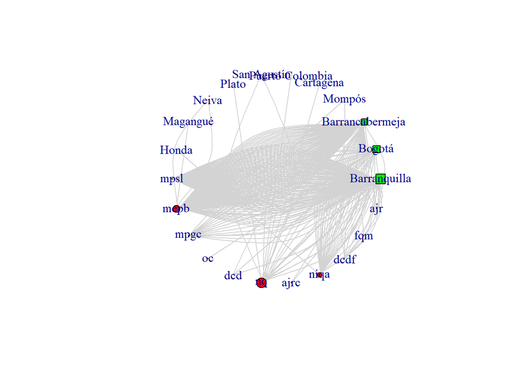

```r
V(bn2)$type <- bipartite_mapping(bn2)$type
V(bn2)$color <- ifelse(V(bn2)$type, "red", "green")
V(bn2)$shape <- ifelse(V(bn2)$type, "circle", "square")
V(bn2)$size <- sqrt(igraph::betweenness(bn2))
E(bn2)$color <- "lightgrey"
plot(bn2, layout = layout_in_circle)
```

```r
bn2.pr <- bipartite.projection(bn2)
```

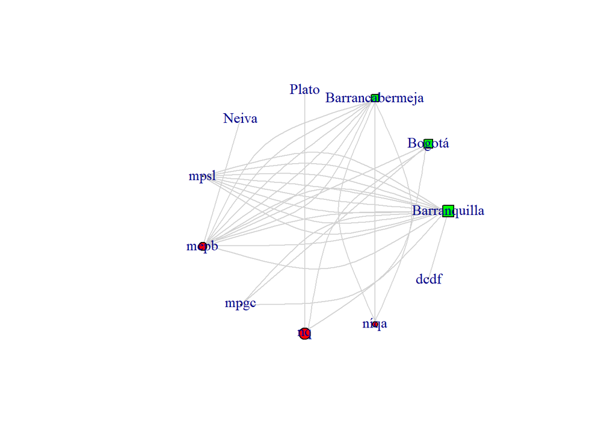

```r
Responsables <- bn2.pr$proj2
Ciudades <- bn2.pr$proj1

ciudades_especificas <- c("Bogotá", "Barrancabermeja", "Barranquilla")
nodos_ciudades_especificas <- V(Ciudades)[V(Ciudades)$name %in% ciudades_especificas]

subgrafo_ciudades_especificas <- subgraph.edges(bn2, E(bn2)[V(bn2)$name %in% names(nodos_ciudades_especificas)])

plot(subgrafo_ciudades_especificas, layout = layout_in_circle)
```

```r
Importantes1 <- degree(Responsables)
Importantes2 <- degree(Ciudades)
```

## La librería “FinancialMaths”

En R, existe una librería de matemáticas financieras de uso sencillo para principiantes en lenguajes de programación. Esta librería se llama [FinancialMaths](https://www.quantargo.com/help/r/latest/packages/FinancialMath/0.1.1) que se desarrolló en Diciembre de 2016.

```r
library(FinancialMath)
```

En esta librería vamos a encontrar funciones muy útiles tales como:

[output not shown]

1. Análisis de Flujos de Caja

```r
cf.analysis(cf=c(1,1,101),times=c(1,2,3),i=.04,time.d=TRUE, plot = TRUE)
```

[output not shown]

```
##       CF Analysis
## PV      91.674727
## MAC D    2.968938
## MOD D    2.854748
## MAC C    8.865665
## MOD C   10.941756
```

Como parte de los resultados que nos arroja la función anterior, tenemos el valor presente (Present Value), la duración y la convexidad de Macaulay y la duración y la convexidad modificadas para flujos de efectivo determinados. También traza la convexidad y el diagrama de tiempo de los flujos de efectivo.

2. Tasa Interna de Retorno (en inglés Internal Rate of Return)

```r
IRR(cf0=100,cf=c(1,1,30,40,50,1),times=c(1,1,3,4,5,6))
```

```
## [1] 0.05166628
```

3. Valor Presente Neto (en inglés NPV) para una serie de flujos de caja y ofrece un diagrama de tiempo de los diagramas de flujo. Por ejemplo, supongamos que tenemos lo siguiente:

```r
NPV(cf0=100,cf=c(50,40),times=c(3,5),i=.01)
```

```
## [1] -13.41187
```

4. Valor Temporal del Dinero: Resuelva el valor presente, el valor futuro, el tiempo o la tasa de interés para la acumulación de dinero que genera interés compuesto. También puede trazar el valor de tiempo para cada período.

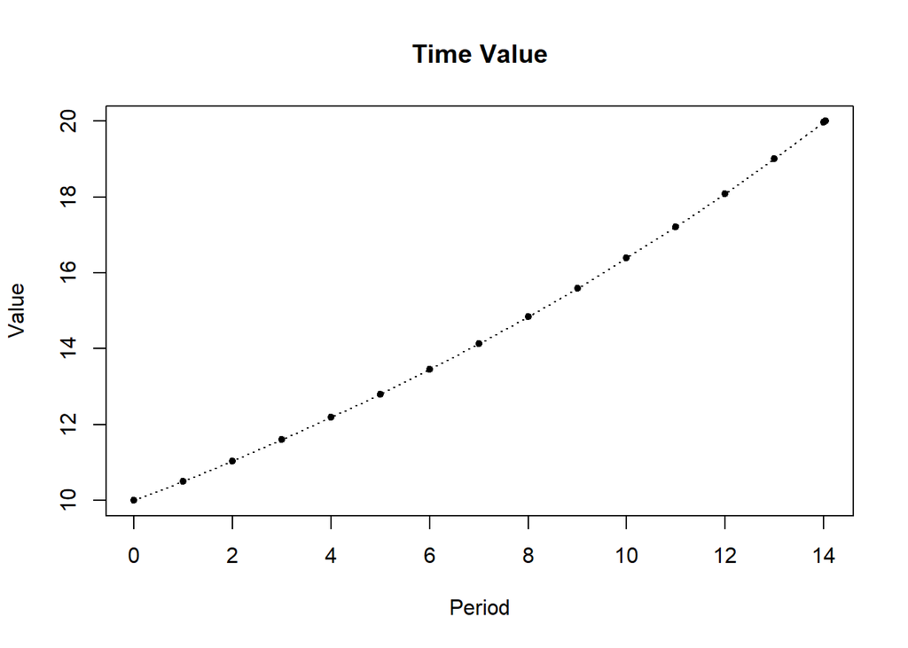

```
##                TVM
## PV       10.000000
## FV       20.000000
## Periods  14.035517
## Eff Rate  0.050625
## i^(2)     0.050000
```

```r
TVM(pv=10,fv=20,i=.05,ic=2,plot=TRUE)
```

5. Tabla de Amortización

```r
amort.table(Loan=1000,n=2,i=.005,ic=1,pf=1)
```

```
## $Schedule
##   Payment Interest Paid Principal Paid Balance
## 1  503.75          5.00         498.75  501.25
## 2  503.75          2.51         501.25    0.00
##
## $Other
##                 Details
## Loan           1000.000
## Total Paid     1007.510
## Total Interest    7.510
## Eff Rate          0.005
```

## Python dentro de R

En las ciencias de datos y analítica de datos, tanto R como Python son lenguajes de programación muy utilizados. Estos lenguajes de programación son integrables dentro de RStudio usando la librería reticulate que instalaremos de la misma manera aplicada para instalar otras librerías.

Ahora, pasamos a insertar un chunk para Python para invocar las librerías de Python.

[figure not shown]

Tipos de Chunk para Archivos RMarkdown en RStudio